# Image Gradients

Gradient(기울기)는 스칼라장(즉, 공간)에서 최대의 증가율을 나타내는 벡터장(방향과 힘)을 뜻합니다.  
영상처리에서 gradient는 영상의 edge 및 그 방향을 찾는 용도로 활용이 되는데요.  
이미지 (x,y)에서의 벡터값(크기와 방향, 즉 밝기와 밝기의 변화하는 방향)을 구해서 해당 pixel이 edge에 얼마나 가까운지,  
그리고 그 방향이 어디인지 쉽게 알수 있게 합니다. (일반적으로 이미지의 Gradient를 생각해보시면 밝기의 변화와 그 방향을 알 수 있습니다.)  
radient（傾ける）はスカラー場（即ち、空間）において最大の増加率を示すベクトル場（方向と力）を意味します。  
映像処理におけるgradientは、映像のedgeやその方向性を探す用途として活用されています。  
画像（x、y）におけるベクトル値（大きさと方向、即ち、明るさと明るさの変化する方向）を求め、そのpixelがedgeにどれだけ近いか、  
そしてその方向がどこであるかを容易に知ることができます。  
（一般的にイメージのグレードアップを考えると、明るさの変化とその方向がわかります。）

## Sobel & Scharr Filter

Gaussian smoothing과 미분을 이용한 방법입니다. 그래서 노이즈가 있는 이미지에 적용하면 좋습니다.  
X축과 Y축을 미분하는 방법으로 경계값을 계산합니다.  
직선을 미분하면 상수, 곡선을 미분하면 또 다른 방정식이 나오는 성질을 이용하여 edge에 대한 선을 그려주는 기능을 합니다.  
X축 미분은 수평선(수직선이 남음), Y축 미분은 수직선(수평선이 남음)을 미분하여 경계가 사라지는 효과가 있습니다.  
미분시 소실되는 표본의 정보가 많을 수 있어 aperture_size 값을 이용하여 소실되는 정도를 조절할 수 있습니다.  
만약 ksize가 -1이면 3x3 Scharr filter가 적용이 되어 Sobel의 3x3보다 좀 더 나은 결과를 보여 줍니다.

Gaussian smoothingと微分を利用した方法です。 だからノイズがあるイメージに適用するといいです。  
X軸とY軸を微分する方法によりしきい値を計算します。  
直線を微分すると定数、曲線を微分するとまた別の方程式が出てくる性質を利用し、edgeに対する線を描く機能をします。  
X軸微分は水平線(垂直線が残る)、Y軸微分は垂直線(水平線が残る)を微分することで境界が消える効果があります。  
未分時に消失する標本の情報が多いため、 aperture_size 値を利用して消失する程度を調節できます。  
もしksizeが-1なら、3x3 Scharrfilterが適用され、Sobelの3x3より良い結果を示します。

#### cv2.Sobel(src, ddepth, dx, dy[, dst[, ksize[, scale[, delta[, borderType]]]]]) → dst

src – input image  
ddepth – output image의 depth, -1なら input imageと同じ.  
dx – x軸の微分の次数.  
dy – y軸の微分の次数.  
ksize – kernel size(ksize x ksize)  
cv2.Scharr(src, ddepth, dx, dy[, dst[, scale[, delta[, borderType]]]]) → dst  
cv2.Sobel() と同じだけどksizeがsobelの3x3より正確に適用されます。

## Laplacian

이미지의 가로와 세로에 대한 Gradient를 2차 미분한 값입니다.  
Sobel filter에 미분의 정도가 더해진 것과 비슷합니다.  
(dx와 dy가 2인 경우) blob(주위의 pixel과 확연한 picel차이를 나타내는 덩어리)검출에 많이 사용됩니다.  
画像の横と縦に対するGradientを二次微分した値です。  
Sobel filterに微分の程度が加わったのと似ています(dxとdyが2の場合)。  
blob（周囲のpixelと明らかなpicel差を示す塊）の検出に多く用いられます。

#### v2.Laplacian(src, ddepth[, dst[, ksize[, scale[, delta[, borderType]]]]]) → dst

src – source image  
ddepth – output iamgeの depth.

### Canny Edge Detection

가장 유명한 Edge Detection방법입니다. 여러 단계의 Algorithm을 통해서 경계를 찾아 냅니다.

1. Noise Reduction  
   이미지의 Noise를 제거합니다. 이때 5x5의 Gaussian filter를 이용합니다.
2. Edge Gradient Detection  
   이미지에서 Gradient의 방향과 강도를 확인합니다. 경계값에서는 주변과 색이 다르기 때문에 미분값이 급속도로 변하게 됩니다.  
   이를 통해 경계값 후보군을 선별합니다.
3. Non-maximum Suppression  
   이미지의 pixel을 Full scan하여 Edge가 아닌 pixel은 제거합니다.
4. Hysteresis Thresholding  
   이제 지금까지 Edge로 판단된 pixel이 진짜 edge인지 판별하는 작업을 합니다.  
   max val과 minVal(임계값)을 설정하여 maxVal 이상은 강한 Edge, min과 max사이는 약한 edge로 설정합니다.  
   이제 약한 edge가 진짜 edge인지 확인하기 위해서 강한 edge와 연결이 되어 있으면 edge로 판단하고, 그러지 않으면 제거합니다.  
   이와 같은 일련의 작업을 통해서 경계값만을 남겨두고 제거합니다.

最も有名なEdge Detection方法です。 複数段階のAlgorithmを通じて境界を見つけます。

1. Noise Reduction  
   画像のNoiseを除去します。 この時、5x5のGaussian filterを利用します。
2. Edge Gradient Detection  
   画像でGradientの方向と強度を確認します。 しきい値では周囲と色が異なるため、微分値が急速に変化します。  
   これによりしきい値候補群を選別します。
3. Non-maximum Suppression  
   画像のpixelをFullscanしてEdgeではないpixelは削除します。
4. Hysteresis Thresholding  
   次に、ここまでEdgeで判断されたpixelが本当にedgeなのかを判別する作業をします。  
   maxvalとminVal（しきい値）を設定し、maxVal以上は強いEdge、minとmax間は弱いedgeに設定します。  
   この後、弱いedgeが本当にedgeなのかを確認するため、強いedgeと結びついていればedgeで判断して、そうでなければ取り除きます。  
   このような一連の作業を通じて、しきい値だけを残して除去します。

#### cv2.Canny(image, threshold1, threshold2[, edges[, apertureSize[, L2gradient]]]) → edges

image – 8-bit input image  
threshold1 – Hysteresis Thredsholding の min の値  
threshold2 – Hysteresis Thredsholding の max の値

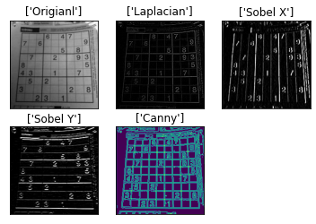

```python
#-*- coding:utf-8 -*-
import cv2
import numpy as np
from matplotlib import pyplot as plt

img = cv2.imread('dave.jpg')
canny = cv2.Canny(img,30,70)

laplacian = cv2.Laplacian(img,cv2.CV_8U)
sobelx = cv2.Sobel(img,cv2.CV_8U,1,0,ksize=3)
sobely = cv2.Sobel(img,cv2.CV_8U,0,1,ksize=3)

images = [img,laplacian, sobelx, sobely, canny]
titles = ['Origianl', 'Laplacian', 'Sobel X', 'Sobel Y','Canny']

for i in range(5):
    plt.subplot(2,3,i+1),plt.imshow(images[i]),plt.title([titles[i]])
    plt.xticks([]),plt.yticks([])

plt.show()
```